# LAB-5 Annova

Aryan Vigyat 20BCE1452

2023-01-31

Attaching the libraries

```r
library(dplyr)
```

```r
library(ggplot2)
library(boot)
```

### Hypothesis

- Null Hypothesis - There is no significant difference between the population means (μ1=μ2=μ3)
- Alternate Hypothesis - There is siginificant difference between the means (μ1≠μ2≠μ3)

## Question 1

1. Loading the Dataset

```r
df=PlantGrowth
summary(df)
```

```
##      weight       group
##  Min.   :3.590   ctrl:10
##  1st Qu.:4.550   trt1:10
##  Median :5.155   trt2:10
##  Mean   :5.073
##  3rd Qu.:5.530
##  Max.   :6.310
```

```r
head(df,5)
```

```
##   weight group
## 1   4.17  ctrl
## 2   5.58  ctrl
## 3   5.18  ctrl
## 4   6.11  ctrl
## 5   4.50  ctrl
```

2. Finding the Group Wise means

```r
df %>%
  group_by(group) %>%
  summarise(mean=mean(weight))
```

```
## # A tibble: 3 × 2
##   group  mean
##   <fct> <dbl>
## 1 ctrl   5.03
## 2 trt1   4.66
## 3 trt2   5.53
```

3. Boxplot

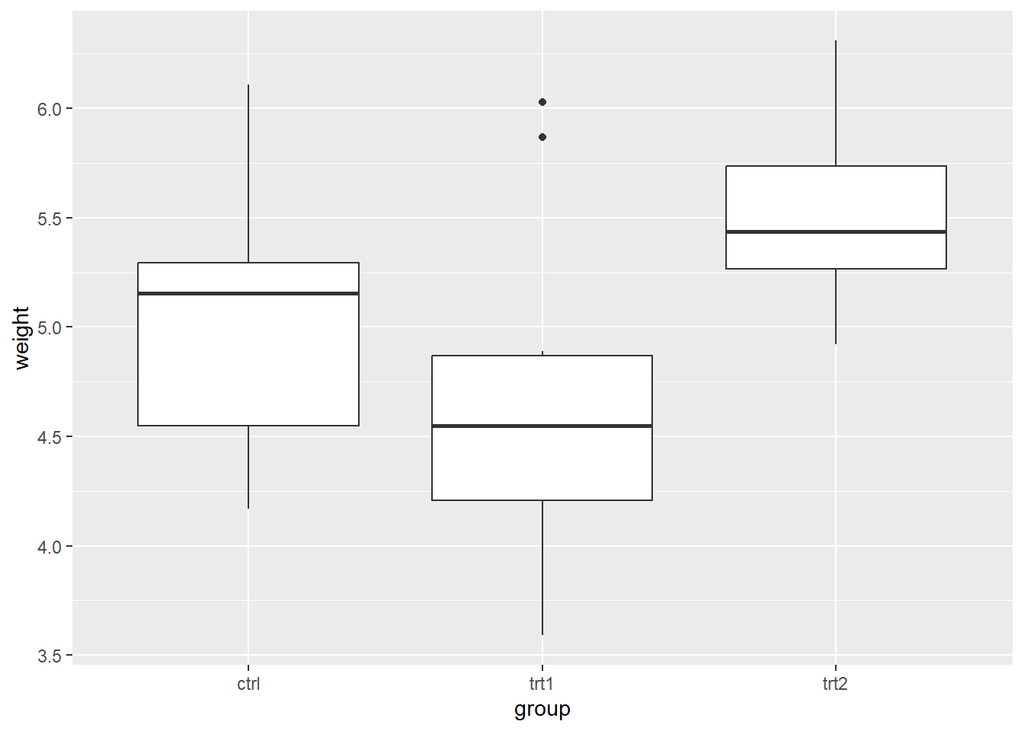

```r
ggplot(df, aes(x=group, y=weight)) +
  geom_boxplot()
```

4. Using Anova Function

```r
ans <-aov(weight~group,data=df)
summary.aov(ans)
```

```
##             Df Sum Sq Mean Sq F value Pr(>F)
## group        2  3.766  1.8832   4.846 0.0159 *
## Residuals   27 10.492  0.3886
## ---
## Signif. codes:  0 '***' 0.001 '**' 0.01 '*' 0.05 '.' 0.1 ' ' 1
```

### Conclusion

The value of P is less than 0.05 so we reject the Null hypothesis to conclude there is a significant difference between the population means now we check the pair wise to conclude which means differences are significant

5. Check which pairs contribute to the difference between the means

```r
TukeyHSD(ans)
```

```
##   Tukey multiple comparisons of means
##     95% family-wise confidence level
##
## Fit: aov(formula = weight ~ group, data = df)
##
## $group
##             diff        lwr       upr     p adj
## trt1-ctrl -0.371 -1.0622161 0.3202161 0.3908711
## trt2-ctrl  0.494 -0.1972161 1.1852161 0.1979960
## trt2-trt1  0.865  0.1737839 1.5562161 0.0120064
```

### Conclusion

The difference between treatment-1 and treatment-2 is significant with an adjusted p-value of 0.012 as we see can in the results obtained above.

## Question 2

1. Loading the Dataset

```r
df2=poisons
df2$poison=as.factor(df2$poison)
df2$treat=as.factor(df2$treat)
```

2.Group Wise Means

```r
df2 %>%
  group_by(poison,treat) %>%
  summarise(mean=mean(time))
```

```
## # A tibble: 12 × 3
## # Groups:   poison [3]
##    poison treat  mean
##    <fct>  <fct> <dbl>
##  1 1      A     0.412
##  2 1      B     0.88
##  3 1      C     0.568
##  4 1      D     0.61
##  5 2      A     0.32
##  6 2      B     0.815
##  7 2      C     0.375
##  8 2      D     0.668
##  9 3      A     0.21
## 10 3      B     0.335
## 11 3      C     0.235
## 12 3      D     0.325
```

3. Boxplot

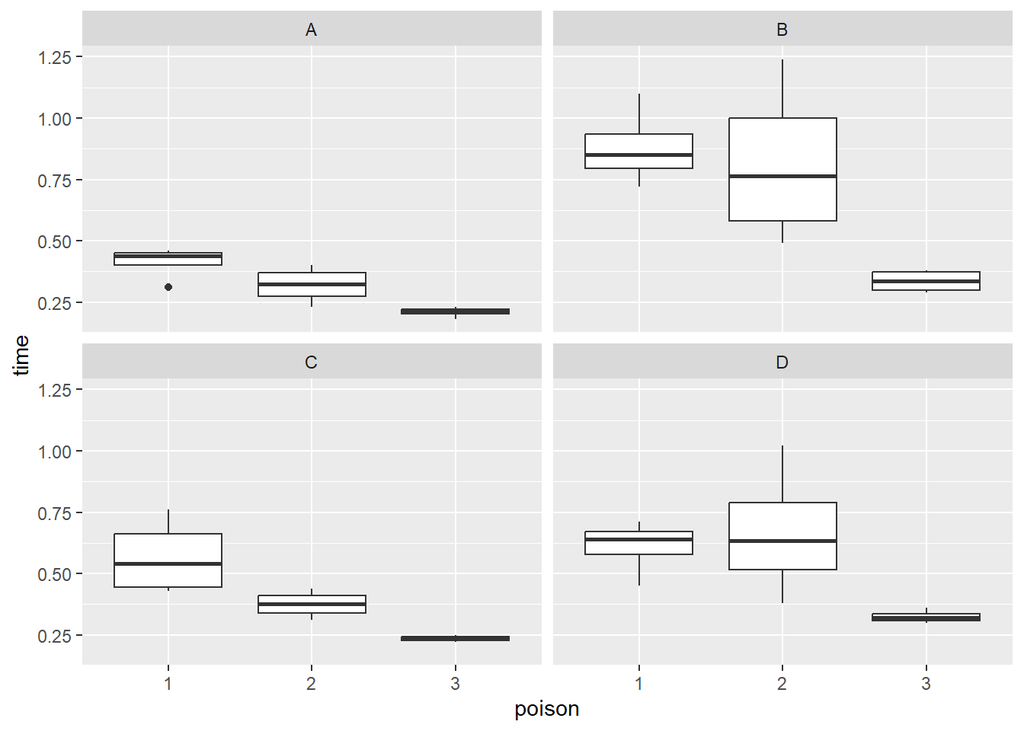

```r
ggplot(df2, aes(x=poison, y=time)) +
  geom_boxplot()+facet_wrap(df2$treat)
```

4. Using Anova Function

```r
ans2 <-aov(time~poison+treat,data=df2)
summary.aov(ans2)
```

```
##             Df Sum Sq Mean Sq F value  Pr(>F)
## poison       2 1.0330  0.5165   20.64 5.7e-07 ***
## treat        3 0.9212  0.3071   12.27 6.7e-06 ***
## Residuals   42 1.0509  0.0250
## ---
## Signif. codes:  0 '***' 0.001 '**' 0.01 '*' 0.05 '.' 0.1 ' ' 1
```

### Conclusion

The value of P is less than 0.05 so we reject the Null hypothesis to conclude there is a significant difference between the population means now we check the pair wise to conclude which means differences are significant

5. Check which pairs contribute to the difference between the means

```r
TukeyHSD(ans2)
```

```
##   Tukey multiple comparisons of means
##     95% family-wise confidence level
##
## Fit: aov(formula = time ~ poison + treat, data = df2)
##
## $poison
##          diff        lwr        upr     p adj
## 2-1 -0.073125 -0.2089936  0.0627436 0.3989657
## 3-1 -0.341250 -0.4771186 -0.2053814 0.0000008
## 3-2 -0.268125 -0.4039936 -0.1322564 0.0000606
##
## $treat
##            diff         lwr         upr     p adj
## B-A  0.36250000  0.18976135  0.53523865 0.0000083
## C-A  0.07833333 -0.09440532  0.25107198 0.6221729
## D-A  0.22000000  0.04726135  0.39273865 0.0076661
## C-B -0.28416667 -0.45690532 -0.11142802 0.0004090
## D-B -0.14250000 -0.31523865  0.03023865 0.1380432
## D-C  0.14166667 -0.03107198  0.31440532 0.1416151
```

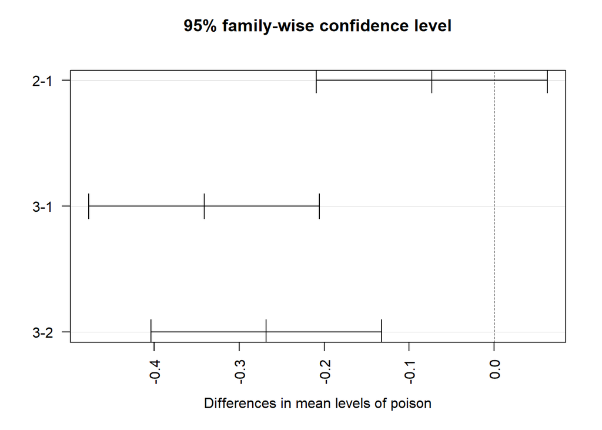

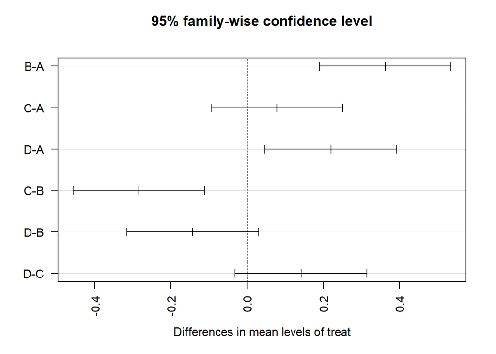

```r
plot(TukeyHSD(ans2,conf.level = 0.95),las = 2)
```

### Conclusion

- The Difference Between B-A treat and 3-1 poison is significant

Time and Date Verification

```r
Sys.info()
```

```
##           sysname           release           version          nodename
##         "Windows"          "10 x64"     "build 22000" "LAPTOP-8VGUQE0S"
##           machine             login              user    effective_user
##          "x86-64"           "ayuar"           "ayuar"           "ayuar"
```

```r
Sys.time()
```

```
## [1] "2023-01-31 20:15:33 IST"
```

```r
Sys.Date()
```

```
## [1] "2023-01-31"
```